# Capstone Milestone Report

Mukund

22 March 2018

## Capstone Milestone Report

Purpose of this Milestone Report is to to display that we have gotten used to working with the data and that we are on track to create your prediction algorithm. This report explains exploratory analysis and goals for the eventual app and algorithm.This document explains major features of the data identified and briefly summarizes plans for creating the prediction algorithm. 1. Data downloading data and loading 2. Summary statistics about the data sets 3. Intrepreting the Data. 4. Further plans

## Data downloading and loading into R

** Data downloading and creating a Data Set involves steps as below **

1. Check if directory already exists?
2. Download data from URL given in course
3. Check if zip file has already been downloaded in CapstoneprojectData directory
4. Now check if the downloaded file is already unzipped or not
5. Create file path files of /final/en_US folder. Note - we will be only working with en_us dataset.
6. Look at individual files for blogs, news and Twitter
7. Make file connections for all txt files

```r
DataURL <- "https://d396qusza40orc.cloudfront.net/dsscapstone/dataset/Coursera-SwiftKey.zip"
if(!file.exists("./CapstoneprojectData/Coursera-SwiftKey.zip")){
  download.file(DataURL,destfile="./CapstoneprojectData/Coursera-SwiftKey.zip",mode = "wb")
}
```

```r
path <- file.path("./CapstoneprojectData/final" , "en_US")
files<-list.files(path, recursive=TRUE)
```

```r
Blogfile <- paste(path,"en_US.blogs.txt",sep="/")
Newsfile <- paste(path,"en_US.news.txt",sep="/")
Twitterfile <- paste(path,"en_US.twitter.txt",sep="/")
```

```r
BlogCon <- file(Blogfile)
NewsCon <- file(Newsfile)
TwitterCon <- file(Twitterfile)
```

## To calculate basic stastics about data we have collected and uploaded.

In this step, we calculate information such as size of file, number of lines, no of charecters etc. and capture the summary in a Table. UTF-8 encoding, while reading files, for multiple language support, though this project only en_US is the lanuage suppoted.

** Load Libraries for further computation **

```r
library(downloader)
library(plyr);
library(dplyr)
library(knitr)
require(stringi)
library(data.table)
library(ggthemes)
library(wordcloud)
library(doParallel)
library(quanteda)
library(ggplot2)
library(ngram)
```

## Create a summary of all counts collected so far in a data drame and add percentages

```r
repo_summary <- data.frame(f_names = c("blogs", "news", "twitter"),
                           f_size  = c(size_of_Blogs, size_of_News, size_of_Twitter),
                           f_lines = c(num_blogs_lines, num_news_lines, num_twitter_lines),
                           n_char =  c(blogs_nchar_sum, news_nchar_sum, twitter_nchar_sum),
                           n_words = c(num_blogs_words, num_news_words, num_twitter_words))

repo_summary <- repo_summary %>% mutate(pct_n_char = round(n_char/sum(n_char), 2))
repo_summary <- repo_summary %>% mutate(pct_lines = round(f_lines/sum(f_lines), 2))
repo_summary <- repo_summary %>% mutate(pct_words = round(n_words/sum(n_words), 2))
kable(repo_summary)
```

| f_names | f_size | f_lines | n_char | n_words | pct_n_char | pct_lines | pct_words |
| --- | --- | --- | --- | --- | --- | --- | --- |
| blogs | 200.4242 | 899288 | 206824505 | 37334131 | 0.54 | 0.27 | 0.53 |
| news | 196.2775 | 77259 | 15639408 | 2643969 | 0.04 | 0.02 | 0.04 |
| twitter | 159.3641 | 2360148 | 162096031 | 30373543 | 0.42 | 0.71 | 0.43 |

## Next step is to create training and testing Samples.

Using training sample we will then create Corpus, Document feature Matrix, frequency tables of features and then plot to do exploratory Analysis.

```r
### create Training and Testing Sample
Train_sample_pct = 0.002
Test_sample_pct = 0.002
set.seed(1001)

Train_blogs_size   <- num_blogs_lines * Train_sample_pct
Train_news_size    <- num_news_lines * Train_sample_pct
Train_twitter_size <- num_twitter_lines * Train_sample_pct

Test_blogs_size   <- num_blogs_lines * Test_sample_pct
Test_news_size    <- num_news_lines * Test_sample_pct
Test_twitter_size <- num_twitter_lines * Test_sample_pct


# Create  Random samples
Train_blogs_sample   <- sample(Bloglines, Train_blogs_size)
Train_news_sample    <- sample(Newslines, Train_news_size)
Train_twitter_sample <- sample(Twitterlines, Train_twitter_size)

Test_blogs_sample   <- sample(Bloglines, Test_blogs_size)
Test_news_sample    <- sample(Newslines, Test_news_size)
Test_twitter_sample <- sample(Twitterlines, Test_twitter_size)
```

Next Step is to create a Training Corpus and use this Corpus for Exploratory Analysis and further analyses We use Quanteda as a package since it is faster and cleaner. We have also used a parallelizing function which multiple cores to paralallelize task. Also, a profanily filter function is used to clean the corpus of Bad Words.

```r
clean_sample <- corpus(Train_repo_sample)
#print(as.character(clean_sample[[1]]))
#' Save clean corpus
saveRDS(clean_sample, file = "./CapstoneprojectData/final/en_US/clean_sample.rds" )

doParallel::registerDoParallel(cores = 2)
options(mc.cores = 2)
```

Break the Corpus and make sentences. The using these sentences, make N-grams ( tokens, 1, 2, 3, 4)

```
## Document-feature matrix of: 6,672 documents, 14,623 features (99.9% sparse).
```

```
## Document-feature matrix of: 6,672 documents, 30,326 features (100% sparse).
```

```
## Document-feature matrix of: 6,672 documents, 16,416 features (100% sparse).
```

```
## Document-feature matrix of: 6,672 documents, 7,971 features (100% sparse).
```

## Plot the frequencies for each n-gram

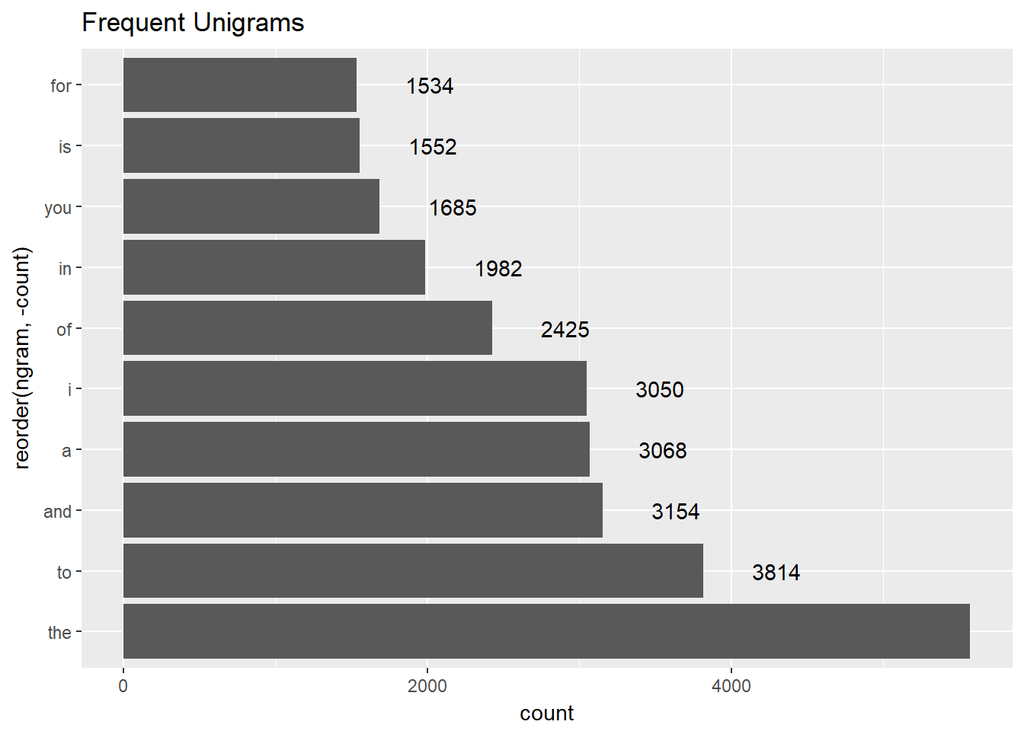

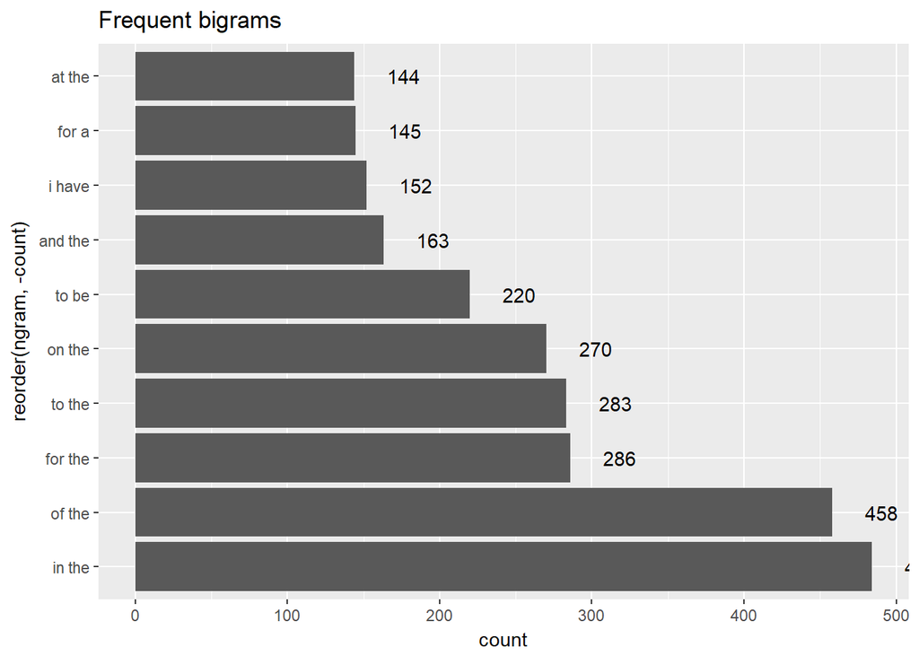

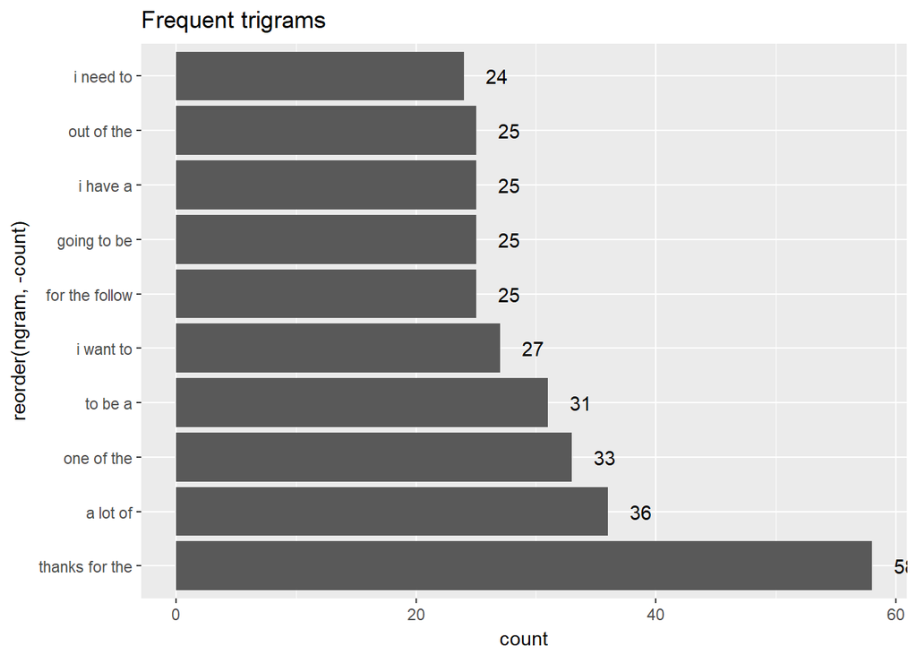

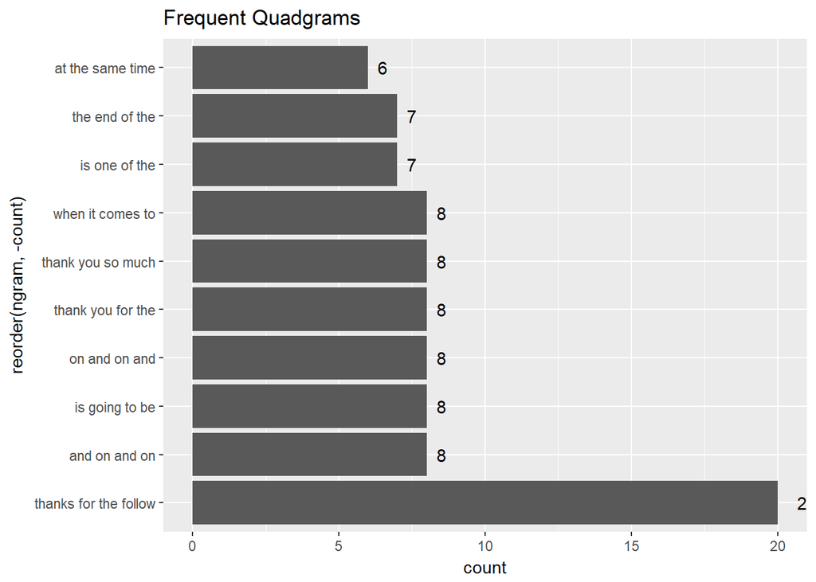

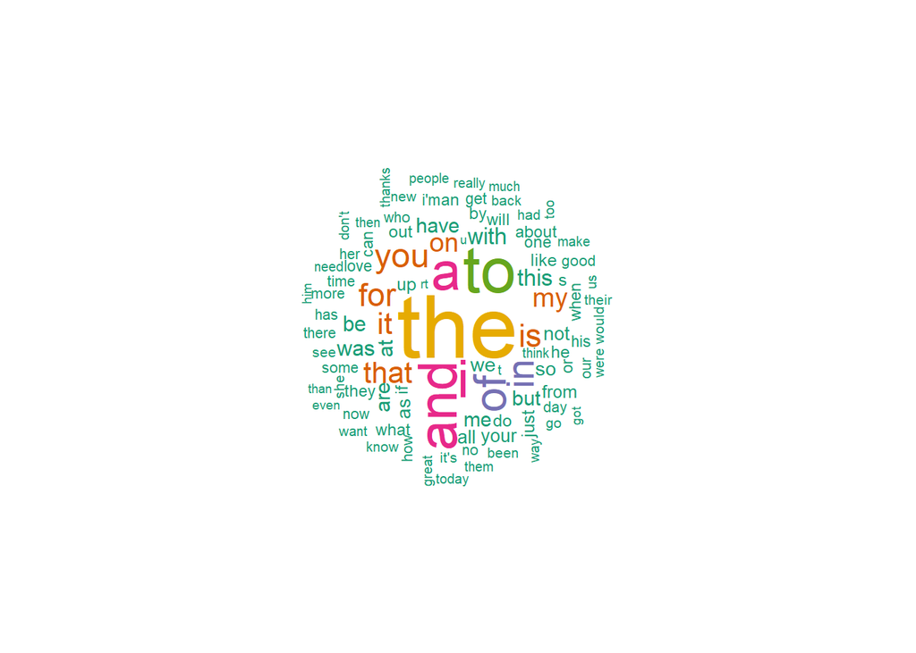

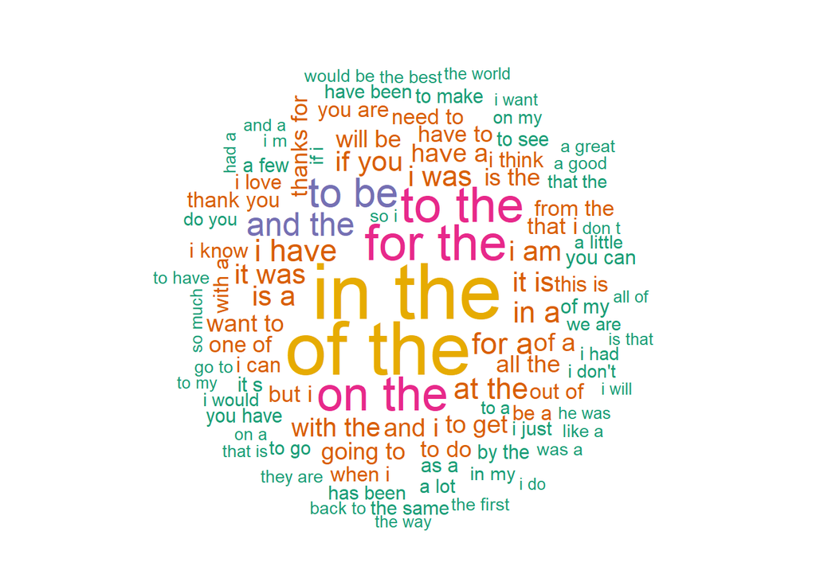

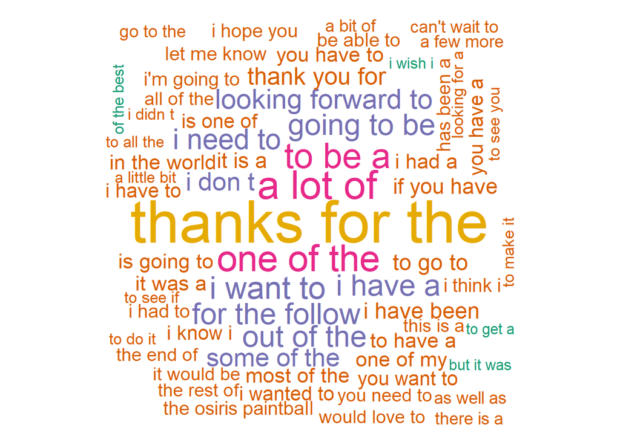

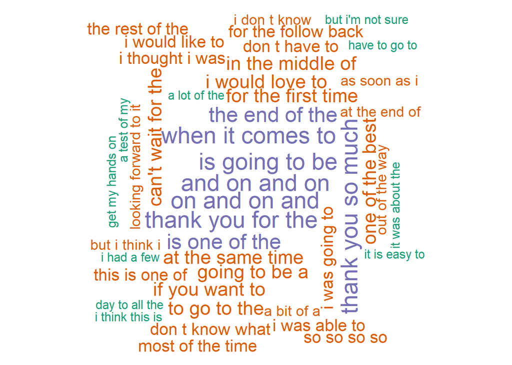

## Next Steps

Next step is to first create a simple Word prediction algorithim using the data set we have blogs, twittter and News. Chances are that such simple prediction algorithim will only predict Word from existing N-gram. Studying literature and other stuff in internet, for a totlly new word/sentence which is not in existing N-gram, we would have to use some somoothing algorithims such as Katz stupid backoff or Kneser Kney. Plan to use Kneser Kney. Once we have some discounted data set from these Algorithims, then use the same in Shiny UI server application. Alternative data source is Test Data set which we have created for Prediction.